# Project Presentation #2

Duc Nguyen

2025-03-20

### I. Load dataset

```r
data <- read.csv("/Users/bebexmimi/Downloads/healthcare-dataset-stroke-data.csv")
head(data)
```

```
##      id gender age hypertension heart_disease ever_married     work_type
## 1  9046   Male  67            0             1          Yes       Private
## 2 51676 Female  61            0             0          Yes Self-employed
## 3 31112   Male  80            0             1          Yes       Private
## 4 60182 Female  49            0             0          Yes       Private
## 5  1665 Female  79            1             0          Yes Self-employed
## 6 56669   Male  81            0             0          Yes       Private
##   Residence_type avg_glucose_level  bmi  smoking_status stroke
## 1          Urban            228.69 36.6 formerly smoked      1
## 2          Rural            202.21  N/A    never smoked      1
## 3          Rural            105.92 32.5    never smoked      1
## 4          Urban            171.23 34.4          smokes      1
## 5          Rural            174.12   24    never smoked      1
## 6          Urban            186.21   29 formerly smoked      1
```

### II. Exploratory Data Analysis (EDA)

```r
library(tidyverse)
library(caret)
library(dplyr)
library(GGally)
str(data)
```

```
## 'data.frame':    5110 obs. of  12 variables:
##  $ id               : int  9046 51676 31112 60182 1665 56669 53882 10434 27419 60491 ...
##  $ gender           : chr  "Male" "Female" "Male" "Female" ...
##  $ age              : num  67 61 80 49 79 81 74 69 59 78 ...
##  $ hypertension     : int  0 0 0 0 1 0 1 0 0 0 ...
##  $ heart_disease    : int  1 0 1 0 0 0 1 0 0 0 ...
##  $ ever_married     : chr  "Yes" "Yes" "Yes" "Yes" ...
##  $ work_type        : chr  "Private" "Self-employed" "Private" "Private" ...
##  $ Residence_type   : chr  "Urban" "Rural" "Rural" "Urban" ...
##  $ avg_glucose_level: num  229 202 106 171 174 ...
##  $ bmi              : chr  "36.6" "N/A" "32.5" "34.4" ...
##  $ smoking_status   : chr  "formerly smoked" "never smoked" "never smoked" "smokes" ...
##  $ stroke           : int  1 1 1 1 1 1 1 1 1 1 ...
```

```r
data$bmi[data$bmi == "NA"] <- NA
data$bmi <- as.numeric(data$bmi)
sum(is.na(data$bmi))
```

```
## [1] 201
```

```r
data$bmi[is.na(data$bmi)] <- mean(data$bmi, na.rm = TRUE)
```

```r
summary(data)
```

```
##        id           gender               age         hypertension
##  Min.   :   67   Length:5110        Min.   : 0.08   Min.   :0.00000
##  1st Qu.:17741   Class :character   1st Qu.:25.00   1st Qu.:0.00000
##  Median :36932   Mode  :character   Median :45.00   Median :0.00000
##  Mean   :36518                      Mean   :43.23   Mean   :0.09746
##  3rd Qu.:54682                      3rd Qu.:61.00   3rd Qu.:0.00000
##  Max.   :72940                      Max.   :82.00   Max.   :1.00000
##  heart_disease     ever_married        work_type         Residence_type
##  Min.   :0.00000   Length:5110        Length:5110        Length:5110
##  1st Qu.:0.00000   Class :character   Class :character   Class :character
##  Median :0.00000   Mode  :character   Mode  :character   Mode  :character
##  Mean   :0.05401
##  3rd Qu.:0.00000
##  Max.   :1.00000
##  avg_glucose_level      bmi        smoking_status         stroke
##  Min.   : 55.12    Min.   :10.30   Length:5110        Min.   :0.00000
##  1st Qu.: 77.25    1st Qu.:23.80   Class :character   1st Qu.:0.00000
##  Median : 91.89    Median :28.40   Mode  :character   Median :0.00000
##  Mean   :106.15    Mean   :28.89                      Mean   :0.04873
##  3rd Qu.:114.09    3rd Qu.:32.80                      3rd Qu.:0.00000
##  Max.   :271.74    Max.   :97.60                      Max.   :1.00000
```

```r
data <- select(data, -id) # Drop 'id' column as it is a unique identifier and does not contribute to prediction
```

```r
num_data <- data %>% select_if(is.numeric)
```

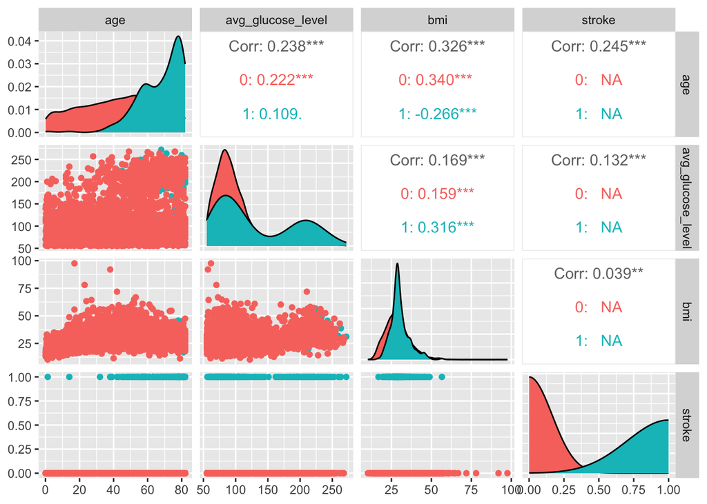

```r
ggpairs(data, columns = c("age", "avg_glucose_level", "bmi", "stroke"),
        aes(color = as.factor(stroke)))
```

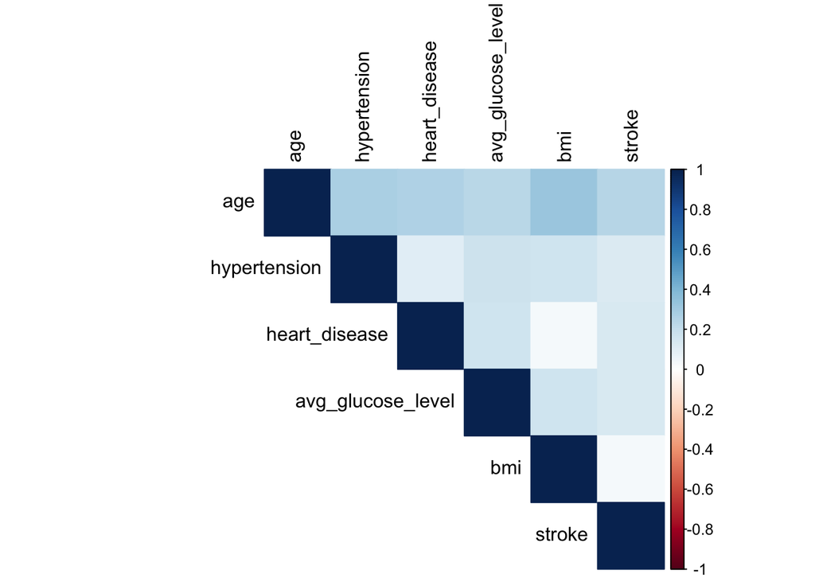

```r
library(corrplot)
cor_matrix <- cor(num_data)
corrplot(cor_matrix, method = "color", type = "upper", tl.col = "black")
```

From the heatmap, it’s evident that most features exhibit minimal correlation with one another, making them well-suited for regression. Among all features, age shows the strongest correlation with stroke.

### III. Model Selection Methods

```r
library(leaps)
```

```r
set.seed(1)
idx <- createDataPartition(data$stroke, p=0.6, list=FALSE)
train.df <- data[idx, ]
holdout.df <- data[-idx, ]
```

#### Best Subset Selection (Cp)

```r
regfit <- regsubsets(stroke ~ ., data = train.df, nvmax = 10)
subset_summary <- summary(regfit)
results <- tibble(
  Size = 1:10,
  Adj_R2 = subset_summary$adjr2,
  Cp = subset_summary$cp,
  BIC = subset_summary$bic
)
results
```

```
## # A tibble: 10 × 4
##     Size Adj_R2    Cp   BIC
##    <int>  <dbl> <dbl> <dbl>
##  1     1 0.0617 84.9  -180.
##  2     2 0.0691 61.1  -197.
##  3     3 0.0757 39.8  -212.
##  4     4 0.0805 24.9  -221.
##  5     5 0.0832 16.7  -223.
##  6     6 0.0850 11.7  -222.
##  7     7 0.0857 10.4  -217.
##  8     8 0.0874  5.52 -216.
##  9     9 0.0879  4.90 -211.
## 10    10 0.0880  5.61 -204.
```

Adjusted R² increases as more predictors are added, peaking at 10 predictors (0.088). However, the improvement becomes marginal beyond 6 predictors (0.08499), suggesting diminishing returns. The best trade-off is typically where Adjusted R² stabilizes, which appears to be around 6 predictors.

BIC (Bayesian Information Criterion) favors model simplicity, reaching its lowest value at 5 predictors (-223.14). This suggests the 5-predictor model is the best fit while avoiding overfitting. Beyond this point, BIC increases, indicating that adding more predictors may introduce unnecessary complexity.

#### Forward Selection Using AIC

```r
forward_aic <- step(lm(stroke ~ 1, data = train.df),
                    scope = list(lower = ~1, upper = ~.),
                    direction = "forward", k = 2)
```

```
## Start:  AIC=-9308.16
## stroke ~ 1
```

```r
summary(forward_aic)
```

```
##
## Call:
## lm(formula = stroke ~ 1, data = train.df)
##
## Residuals:
##      Min       1Q   Median       3Q      Max
## -0.05055 -0.05055 -0.05055 -0.05055  0.94945
##
## Coefficients:
##             Estimate Std. Error t value Pr(>|t|)
## (Intercept) 0.050554   0.003957   12.78   <2e-16 ***
## ---
## Signif. codes:  0 '***' 0.001 '**' 0.01 '*' 0.05 '.' 0.1 ' ' 1
##
## Residual standard error: 0.2191 on 3065 degrees of freedom
```

#### Backward Elimination Using AIC

```r
backward_aic <- step(lm(stroke ~ ., data = train.df),
                     direction = "backward", k = 2)
```

```
## Start:  AIC=-9569.25
## stroke ~ gender + age + hypertension + heart_disease + ever_married +
##     work_type + Residence_type + avg_glucose_level + bmi + smoking_status
##
##                     Df Sum of Sq    RSS     AIC
## - smoking_status     3    0.0554 133.80 -9574.0
## - gender             2    0.0060 133.75 -9573.1
## - Residence_type     1    0.0034 133.75 -9571.2
## <none>                           133.75 -9569.3
## - bmi                1    0.1071 133.85 -9568.8
## - work_type          4    0.4405 134.19 -9567.2
## - ever_married       1    0.4049 134.15 -9562.0
## - avg_glucose_level  1    0.4166 134.16 -9561.7
## - heart_disease      1    0.6001 134.35 -9557.5
## - hypertension       1    0.8289 134.58 -9552.3
## - age                1    5.0677 138.81 -9457.2
##
## Step:  AIC=-9573.98
## stroke ~ gender + age + hypertension + heart_disease + ever_married +
##     work_type + Residence_type + avg_glucose_level + bmi
##
##                     Df Sum of Sq    RSS     AIC
## - gender             2    0.0084 133.81 -9577.8
## - Residence_type     1    0.0043 133.81 -9575.9
## <none>                           133.80 -9574.0
## - bmi                1    0.1102 133.91 -9573.5
## - work_type          4    0.5569 134.36 -9569.3
## - ever_married       1    0.3963 134.20 -9566.9
## - avg_glucose_level  1    0.4162 134.22 -9566.5
## - heart_disease      1    0.6171 134.42 -9561.9
## - hypertension       1    0.8000 134.60 -9557.7
## - age                1    5.1216 138.92 -9460.8
##
## Step:  AIC=-9577.79
## stroke ~ age + hypertension + heart_disease + ever_married +
##     work_type + Residence_type + avg_glucose_level + bmi
##
##                     Df Sum of Sq    RSS     AIC
## - Residence_type     1    0.0040 133.81 -9579.7
## <none>                           133.81 -9577.8
## - bmi                1    0.1095 133.92 -9577.3
## - work_type          4    0.5757 134.39 -9572.6
## - ever_married       1    0.3935 134.21 -9570.8
## - avg_glucose_level  1    0.4222 134.23 -9570.1
## - heart_disease      1    0.6331 134.44 -9565.3
## - hypertension       1    0.8045 134.62 -9561.4
## - age                1    5.1245 138.94 -9464.6
##
## Step:  AIC=-9579.7
## stroke ~ age + hypertension + heart_disease + ever_married +
##     work_type + avg_glucose_level + bmi
##
##                     Df Sum of Sq    RSS     AIC
## <none>                           133.81 -9579.7
## - bmi                1    0.1095 133.93 -9579.2
## - work_type          4    0.5778 134.39 -9574.5
## - ever_married       1    0.3929 134.21 -9572.7
## - avg_glucose_level  1    0.4251 134.24 -9572.0
## - heart_disease      1    0.6345 134.45 -9567.2
## - hypertension       1    0.8011 134.62 -9563.4
## - age                1    5.1298 138.94 -9466.4
```

```r
summary(backward_aic)
```

```
##
## Call:
## lm(formula = stroke ~ age + hypertension + heart_disease + ever_married +
##     work_type + avg_glucose_level + bmi, data = train.df)
##
## Residuals:
##      Min       1Q   Median       3Q      Max
## -0.32854 -0.08059 -0.02248  0.00621  1.02631
##
## Coefficients:
##                          Estimate Std. Error t value Pr(>|t|)
## (Intercept)            -2.429e-02  1.680e-02  -1.445 0.148437
## age                     3.029e-03  2.799e-04  10.822  < 2e-16 ***
## hypertension            5.765e-02  1.348e-02   4.276 1.96e-05 ***
## heart_disease           6.639e-02  1.744e-02   3.806 0.000144 ***
## ever_marriedYes        -3.374e-02  1.127e-02  -2.995 0.002767 **
## work_typeGovt_job      -6.340e-02  1.884e-02  -3.365 0.000774 ***
## work_typeNever_worked  -2.910e-02  4.927e-02  -0.591 0.554802
## work_typePrivate       -5.075e-02  1.551e-02  -3.272 0.001078 **
## work_typeSelf-employed -6.458e-02  1.940e-02  -3.328 0.000885 ***
## avg_glucose_level       2.739e-04  8.791e-05   3.115 0.001855 **
## bmi                    -8.754e-04  5.536e-04  -1.581 0.113913
## ---
## Signif. codes:  0 '***' 0.001 '**' 0.01 '*' 0.05 '.' 0.1 ' ' 1
##
## Residual standard error: 0.2093 on 3055 degrees of freedom
## Multiple R-squared:  0.09071,    Adjusted R-squared:  0.08773
## F-statistic: 30.48 on 10 and 3055 DF,  p-value: < 2.2e-16
```

#### Stepwise Selection Using AIC

```r
stepwise_aic <- step(lm(stroke ~., data = train.df),
                     scope = list(lower = ~1, upper = ~.),
                     direction = "both", k = 2)
```

```
## Start:  AIC=-9569.25
## stroke ~ gender + age + hypertension + heart_disease + ever_married +
##     work_type + Residence_type + avg_glucose_level + bmi + smoking_status
##
##                     Df Sum of Sq    RSS     AIC
## - smoking_status     3    0.0554 133.80 -9574.0
## - gender             2    0.0060 133.75 -9573.1
## - Residence_type     1    0.0034 133.75 -9571.2
## <none>                           133.75 -9569.3
## - bmi                1    0.1071 133.85 -9568.8
## - work_type          4    0.4405 134.19 -9567.2
## - ever_married       1    0.4049 134.15 -9562.0
## - avg_glucose_level  1    0.4166 134.16 -9561.7
## - heart_disease      1    0.6001 134.35 -9557.5
## - hypertension       1    0.8289 134.58 -9552.3
## - age                1    5.0677 138.81 -9457.2
##
## Step:  AIC=-9573.98
## stroke ~ gender + age + hypertension + heart_disease + ever_married +
##     work_type + Residence_type + avg_glucose_level + bmi
##
##                     Df Sum of Sq    RSS     AIC
## - gender             2    0.0084 133.81 -9577.8
## - Residence_type     1    0.0043 133.81 -9575.9
## <none>                           133.80 -9574.0
## - bmi                1    0.1102 133.91 -9573.5
## + smoking_status     3    0.0554 133.75 -9569.3
## - work_type          4    0.5569 134.36 -9569.3
## - ever_married       1    0.3963 134.20 -9566.9
## - avg_glucose_level  1    0.4162 134.22 -9566.5
## - heart_disease      1    0.6171 134.42 -9561.9
## - hypertension       1    0.8000 134.60 -9557.7
## - age                1    5.1216 138.92 -9460.8
##
## Step:  AIC=-9577.79
## stroke ~ age + hypertension + heart_disease + ever_married +
##     work_type + Residence_type + avg_glucose_level + bmi
##
##                     Df Sum of Sq    RSS     AIC
## - Residence_type     1    0.0040 133.81 -9579.7
```

[output cut: 12 more lines]

```
## stroke ~ age + hypertension + heart_disease + ever_married +
##     work_type + avg_glucose_level + bmi
##
##                     Df Sum of Sq    RSS     AIC
## <none>                           133.81 -9579.7
## - bmi                1    0.1095 133.93 -9579.2
## + Residence_type     1    0.0040 133.81 -9577.8
## + gender             2    0.0082 133.81 -9575.9
## + smoking_status     3    0.0587 133.76 -9575.0
## - work_type          4    0.5778 134.39 -9574.5
## - ever_married       1    0.3929 134.21 -9572.7
## - avg_glucose_level  1    0.4251 134.24 -9572.0
## - heart_disease      1    0.6345 134.45 -9567.2
## - hypertension       1    0.8011 134.62 -9563.4
## - age                1    5.1298 138.94 -9466.4
```

```r
summary(stepwise_aic)
```

```
##
## Call:
## lm(formula = stroke ~ age + hypertension + heart_disease + ever_married +
##     work_type + avg_glucose_level + bmi, data = train.df)
##
## Residuals:
##      Min       1Q   Median       3Q      Max
## -0.32854 -0.08059 -0.02248  0.00621  1.02631
##
## Coefficients:
##                          Estimate Std. Error t value Pr(>|t|)
## (Intercept)            -2.429e-02  1.680e-02  -1.445 0.148437
## age                     3.029e-03  2.799e-04  10.822  < 2e-16 ***
## hypertension            5.765e-02  1.348e-02   4.276 1.96e-05 ***
## heart_disease           6.639e-02  1.744e-02   3.806 0.000144 ***
## ever_marriedYes        -3.374e-02  1.127e-02  -2.995 0.002767 **
## work_typeGovt_job      -6.340e-02  1.884e-02  -3.365 0.000774 ***
## work_typeNever_worked  -2.910e-02  4.927e-02  -0.591 0.554802
## work_typePrivate       -5.075e-02  1.551e-02  -3.272 0.001078 **
## work_typeSelf-employed -6.458e-02  1.940e-02  -3.328 0.000885 ***
## avg_glucose_level       2.739e-04  8.791e-05   3.115 0.001855 **
## bmi                    -8.754e-04  5.536e-04  -1.581 0.113913
## ---
## Signif. codes:  0 '***' 0.001 '**' 0.01 '*' 0.05 '.' 0.1 ' ' 1
##
## Residual standard error: 0.2093 on 3055 degrees of freedom
## Multiple R-squared:  0.09071,    Adjusted R-squared:  0.08773
## F-statistic: 30.48 on 10 and 3055 DF,  p-value: < 2.2e-16
```

The stepwise selection method, like backward elimination, retains the same significant predictors, including age, hypertension, heart disease, work type, and avg glucose level, while excluding BMI and Never worked. This suggests that stepwise selection agrees with backward elimination in terms of the most important predictors.

The model’s explanatory power (R-squared = 9%) remains low, suggesting potential for improvement, perhaps by considering additional variables or more complex modeling techniques.

### IV. Regularization and Cross-Validation

```r
library(glmnet)
library(caret)
library(pROC)
set.seed(456)

X_stroke <- model.matrix(stroke ~ ., data)[, -1]
y_stroke <- as.numeric(data$stroke)

# Custom function to compute AUC for a given lambda across 5-fold CV
auc_cv <- function(lambda, x, y, folds) {
  pred <- numeric(length(y))
  for (i in unique(folds)) {
    train_idx <- which(folds != i)
    test_idx <- which(folds == i)
    fit <- glmnet(x[train_idx, ], y[train_idx], family = "binomial", alpha = 1, lambda = lambda)
    pred[test_idx] <- predict(fit, newx = x[test_idx, ], s = lambda, type = "response")
  }
  roc_obj <- roc(y, pred)
  auc(roc_obj)
}

# Perform 5-fold CV to tune lambda based on AUC
set.seed(789)
folds <- createFolds(y_stroke, k = 5, list = FALSE)

# Generate a grid of lambda values from cv.glmnet
lambda_grid <- cv.glmnet(X_stroke, y_stroke, family = "binomial", alpha = 1, nfolds = 5)$lambda
auc_values <- sapply(lambda_grid, auc_cv, x = X_stroke, y = y_stroke, folds = folds)
# Select the lambda value that gives the maximum AUC
best_lambda_auc <- lambda_grid[which.max(auc_values)]

# Run cv.glmnet with the best lambda for LASSO (alpha = 1)
cv_lasso_log <- cv.glmnet(X_stroke, y_stroke, family = "binomial", alpha = 1, nfolds = 5)

# Print the model coefficients at the best lambda value
lasso_coefs <- coef(cv_lasso_log, s = best_lambda_auc)
print(lasso_coefs)
```

```
## 17 x 1 sparse Matrix of class "dgCMatrix"
##                                     s1
## (Intercept)                -6.42441743
## genderMale                  .
## genderOther                 .
## age                         0.05554360
## hypertension                0.24856914
## heart_disease               0.24016114
## ever_marriedYes             .
## work_typeGovt_job           .
## work_typeNever_worked       .
## work_typePrivate            .
## work_typeSelf-employed      .
## Residence_typeUrban         .
## avg_glucose_level           0.00296555
## bmi                         .
## smoking_statusnever smoked  .
## smoking_statussmokes        .
## smoking_statusUnknown       .
```

The logistic regression model shows that age, hypertension, heart disease, and average glucose level are significant factors in predicting stroke risk. As age increases, the likelihood of having a stroke also increases. Both hypertension and heart disease raise the risk, while glucose levels have a small positive effect. Other variables like gender, work type, and smoking status were excluded from the model, indicating they are less important in predicting stroke risk.

```r
preds <- predict(cv_lasso_log, X_stroke, s = best_lambda_auc, type = "response")
lasso_logistic_class <- ifelse(preds > 0.5, 1, 0)

# Convert both predictions and true labels to factors with the same levels
lasso_logistic_class <- factor(lasso_logistic_class, levels = c(0, 1))
actual_class <- factor(y_stroke, levels = c(0, 1))

# Now create the confusion matrix
conf_matrix <- confusionMatrix(lasso_logistic_class, actual_class)
print(conf_matrix$table)
```

```
##           Reference
## Prediction    0    1
##          0 4861  249
##          1    0    0
```

True Negatives (TN): 4861 – The model correctly predicted no stroke (negative class) for 4861 instances.

True Positives (TP): 0 – The model did not correctly predict any stroke cases (there were no true positives).

```r
sensitivity <- conf_matrix$byClass["Sensitivity"]
specificity <- conf_matrix$byClass["Specificity"]
roc_curve <- roc(y_stroke, preds)
auc_val <- auc(roc_curve)

cat("Best Lambda for LASSO Logistic (AUC):", best_lambda_auc, "\n")
```

```
## Best Lambda for LASSO Logistic (AUC): 0.006213992
```

```r
cat("Sensitivity:", sensitivity, " Specificity:", specificity, " AUC:", auc_val, "\n")
```

```
## Sensitivity: 1  Specificity: 0  AUC: 0.8438866
```

The AUC of 0.8439 suggests the model has a good ability to discriminate between classes, but improvements are needed to improve sensitivity (detection of strokes).

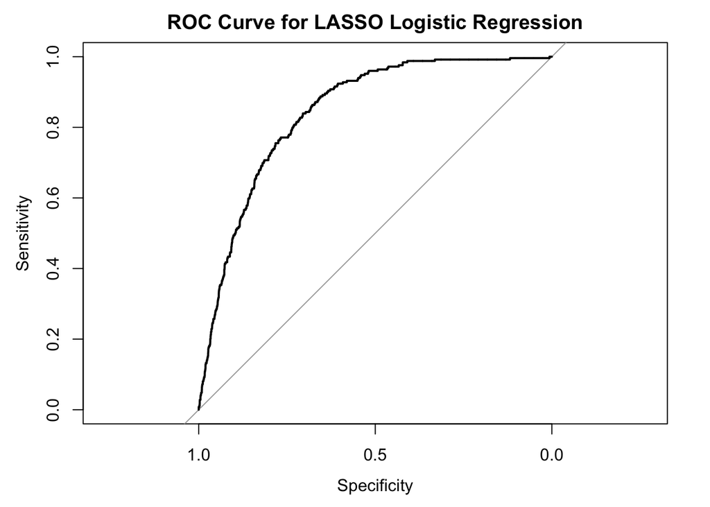

```r
plot(roc_curve, main = "ROC Curve for LASSO Logistic Regression")
```

### V. Model Performance Evaluation

1. Compare different model selection methods and justify the final model choice.
- Best Subset Selection:

Adjusted R² increases with the addition of more predictors, peaking at 10 predictors (Adjusted R² = 0.088). However, the increase becomes marginal after 6 predictors (Adjusted R² = 0.08499), suggesting diminishing returns. The 6-predictor model strikes the best trade-off between explanatory power and complexity.

BIC (Bayesian Information Criterion): BIC reaches its lowest value at 5 predictors (-223.14), indicating that the 5-predictor model offers the best balance between fit and simplicity. Adding more predictors beyond this point results in higher BIC values, indicating unnecessary complexity.

- Stepwise Selection (Forward, Backward, and Mixed):

Both the stepwise selection and backward elimination methods align in identifying the most important predictors. In the Forward AIC method, the model initially only includes the intercept, which is highly significant, meaning the model does not yet include any predictors. The intercept’s statistical reliability suggests a solid foundation, but additional predictors must be added in subsequent steps of the forward selection process to build a more meaningful predictive model.

The R-squared value of 9% indicates that the model explains a modest portion of the variability, leaving room for improvement, possibly through additional predictors or more advanced modeling techniques.

- Lasso Logistic Regression with Cross-Validation:

Cross-validation was employed for Lasso logistic regression, which played a crucial role in selecting the final model. Lasso not only helps with variable selection by penalizing the inclusion of less important predictors but also regularizes the model to avoid overfitting. Cross-validation ensures that the model is evaluated across different subsets of the data, providing a robust estimate of its performance and enhancing its ability to generalize to new data.

The Lasso model retained the following significant predictors: age, hypertension, heart disease, and average glucose level. These predictors were deemed essential for predicting stroke risk. Other variables like gender, work type, BMI, and smoking status were excluded from the model, indicating that they did not contribute meaningfully to stroke prediction after regularization.

2. Discuss potential overfitting issues and how cross-validation helps mitigate them.

Overfitting occurs when a model learns not only the true underlying patterns in the data but also the noise and random fluctuations, leading to excellent performance on the training data but poor generalization to new, unseen data. In this case, overfitting might happen if the model is too complex, incorporating too many predictors or overemphasizing certain features, leading to high specificity but zero sensitivity (failing to detect any positive cases like strokes).

Cross-validation helps mitigate overfitting by splitting the dataset into multiple folds, training the model on one subset, and validating it on another. This process ensures that the model is evaluated on data it hasn’t seen before, providing a more reliable estimate of its performance. By using cross-validation, you can assess the model’s ability to generalize and adjust it accordingly to prevent overfitting. It also allows for fine-tuning the model’s parameters and regularization techniques to strike the right balance between bias and variance, ensuring that the model performs well both on training and unseen data.

3. Present key takeaways from the model selection process.

Importance of Cross-Validation: Cross-validation ensures the model generalizes well, preventing overfitting and improving its robustness by evaluating its performance on different data subsets.

Variable Selection: Techniques like Lasso and stepwise selection identified key predictors (e.g., age, hypertension, heart disease, and glucose levels) as significant, while reducing noise by excluding irrelevant variables.

Model Performance: The model demonstrated good discrimination with an AUC of 0.8439, but sensitivity improvements are necessary, highlighting the importance of fine-tuning for detecting positive cases (strokes).